# Supplementary material - What’s in the *r*? A review of the usage of the r symbol in the *Illustrations of the IPA*

Anselme, Rémi, François Pellegrino & Dan Dediu

2022-08-02 18:09:30

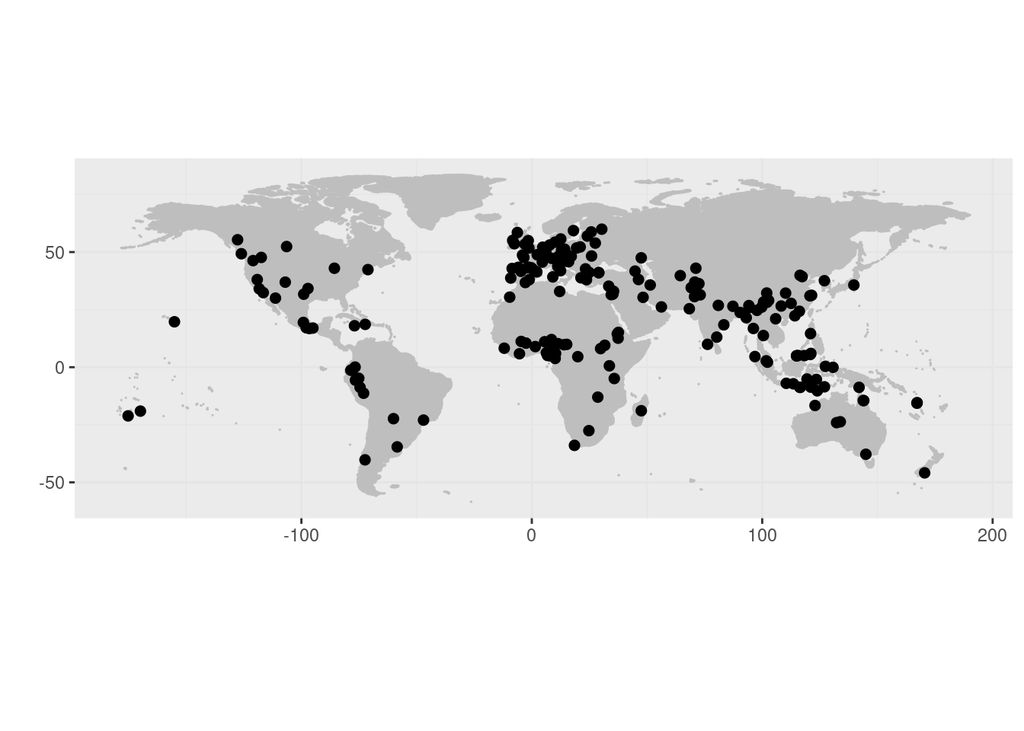

*Figure 1.* *Distribution of the languages covered by the *Illustrations of the IPA* (not included in the article). All coordinates for all datapoints were retreived manually based on the information available in the *Illustrations*.*

# Results

## General results

### Year of publication

Here we look at the number of articles published each year.

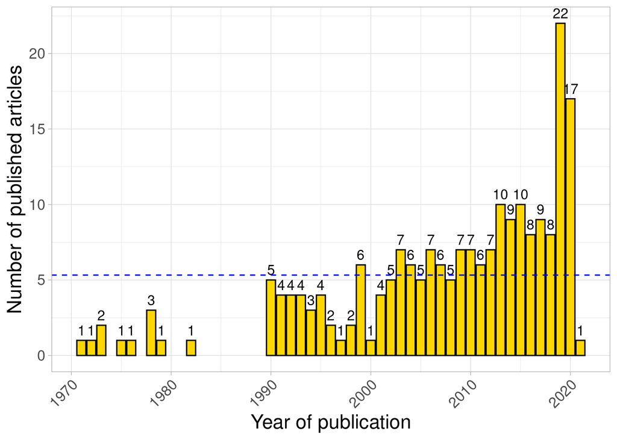

*Figure 2.* *Number of publications per year (yellow bars) with their average across all years (horizontal blue dashed line). Please note that some very recent Illustrations might not yet be included in an official issue but only available on the journal’s website as preprints.*

- 46 Illustrations were published before 2000.

### Informant characteristics

Here we look at the informant characteristics.

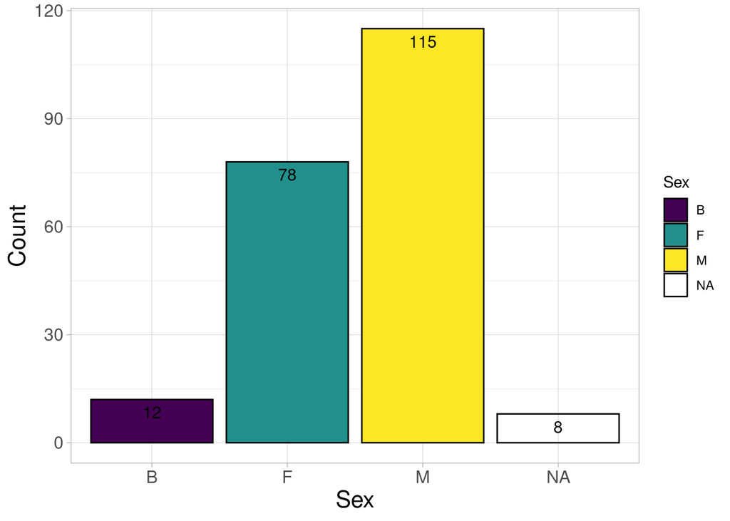

*Figure 3.* *The distribution of the sex of the informant(s). Notations: F = Female; M = Male; B = the recording of 1M & 1F used for the transcription; NA = data not communicated.*

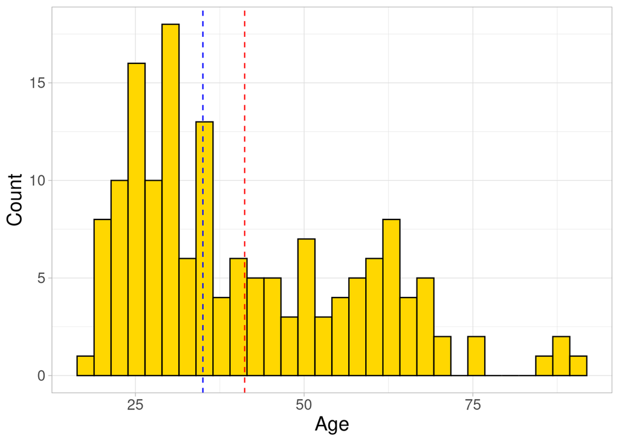

*Figure 4.* *The distribution of the age of the informant(s) with mean 41 (red dashed vertical line) and median (blue dashed vertical line.*

### Geographic distribution, families and population size

#### Macroareas

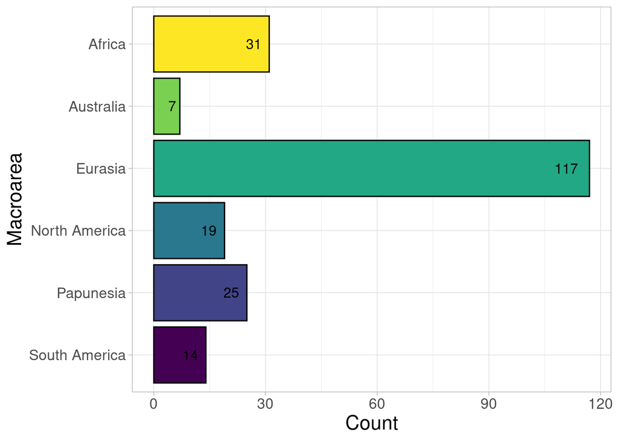

*Figure 5.* *Distribution of languages by macroarea.*

It can be seen that there is an over-representation of Eurasian languages, with just a few Australian languages.

#### Language families

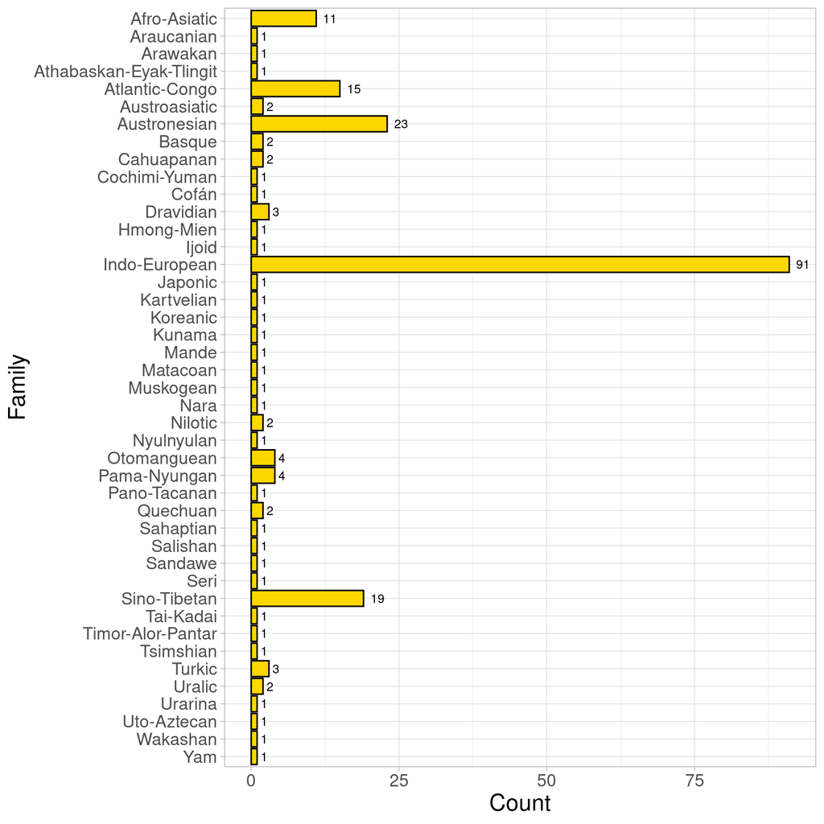

*Figure 6.* *Distribution of languages by family.*

Indo-european languages are over-sampled.

#### Speaker population size

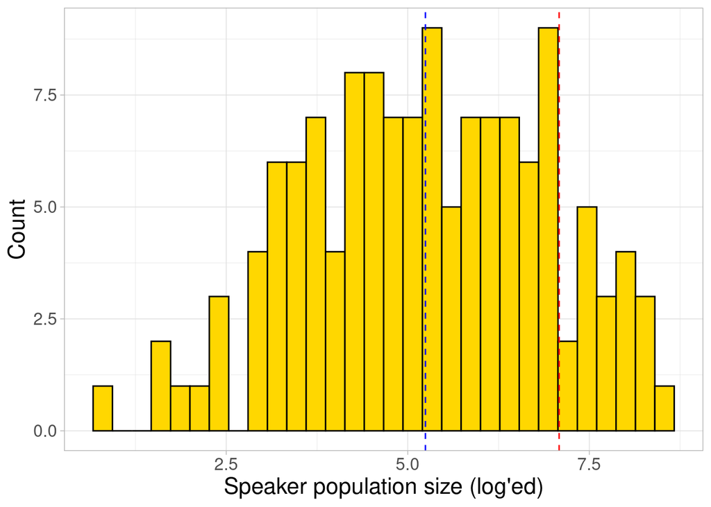

*Figure 7.* *The distribution of the log speaker population size, showing the mean (12,000,000 or 7.08 on the log scale; red dashed vertical line) and the median (175,000 or 5.24 on log scale blue dashed vertical line)*

## Transcriptions

### Phonetic and phonemic transcriptions

We give the followings counts for the classification of the transcriptions before any revision:

- 54 illustrations with a phonetic transcription and a phonemic transcription
- 47 illustrations with only a phonetic transcription
- 38 illustrations with only a phonemic transcription
- 73 illustrations for which we lack information
- 1 illustration with no transcription

We decided to consider that all transcriptions lacking of explicit mention of *phonetic*/*phonemic*/*broad*/*narrow* (here considered as *unknown*) should be considered as *phonetic*. So, over the 213 illustrations, we have in total :

- 174 phonetic transcriptions
- 92 phonemic transcriptions

Including:

- 54 illustrations with a phonetic transcription and a phonemic transcription
- 120 illustrations with only a phonetic transcription
- 38 illustrations with only a phonemic transcription
- 1 illustrations with no transcription

### Orthographic transcription and transliteration

Among the illustrations, there are several orthographic systems among which the Latin alphabet. It should be taken into account that not all the languages studied have an orthographic system.

So, over the 213 illustrations, we have in total :

- 134 illustrations with an `<r>` in the orthography of the language or in its transliteration
  - 47 illustrations for which *a priori* double `<rr>` exist in the orthographic system
- 13 illustrations without *a priori* an `<r>` in the orthography of the language
- And 66 illustrations where nothing can be said because either the language has no spelling, or the language is written in another system than the Latin alphabet (and no transliteration is given).

## ‘r-like’ sounds

### r in transcriptions

As we are mainly interested in *r*, we have chosen to analyze only some illustrations. We counted the possible cases with an *r*. In other words, we looked at the illustrations where:

- There is an /r/ present in the consonant table of the illustration
- There is at least one [r] or /r/ in one of the transcriptions

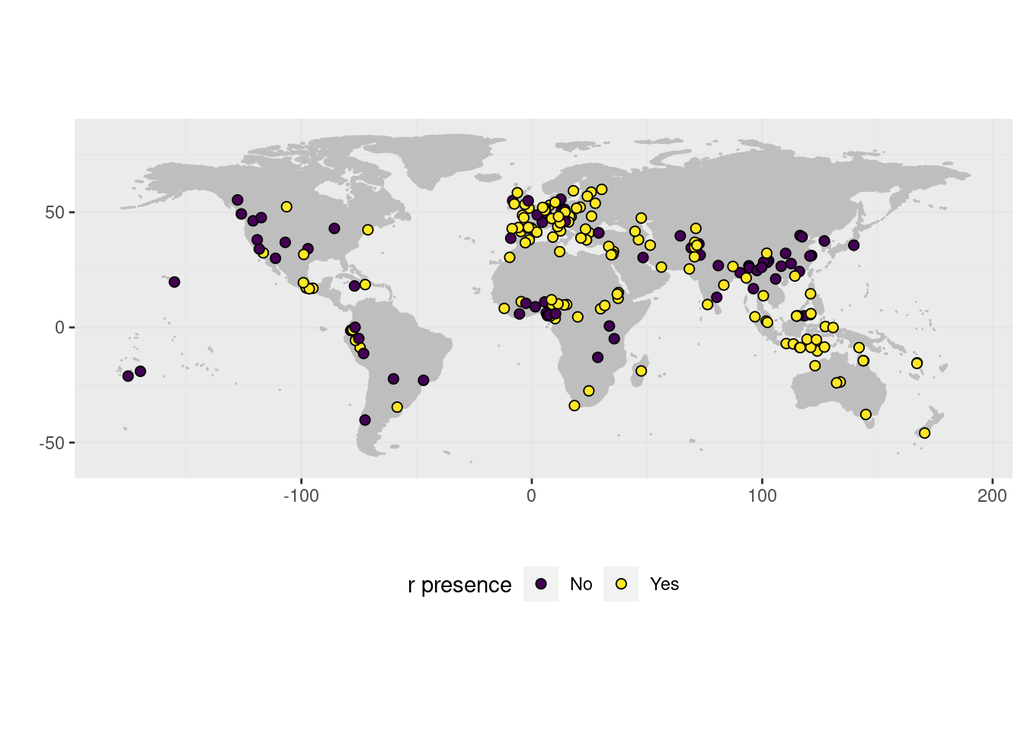

*Figure 8.* *Distribution of the languages where at least an *r* was found in a transcription of the narrative and/or in the consonant chart of the Illustration.*

This gives us 136 illustrations to work with including :

- 105 illustrations with at least one /r/ of which :
  - 84 have “trill” or “rolled” in their name
  - 16 do not have “trill” or “rolled” in their name
  - 5 have no description in terms of place and way of articulation of the symbol

All the following the following Sankey diagrams have been retouched on Inkscape add labels and change the aesthetics before to be included in the final manuscript.

#### Illustrations with both phonemic and phonetic transcriptions

[interactive chart not shown]

*Figure 9.* *Sankey diagram for counts of Illustrations with both phonemic and phonetic transcriptions when there is at least one r in the Illustration, focusing on the phonemic transcription (left), the consonant chart (middle) and the phonetic transcription (right). Plus symbol + means the presence of a symbol in the narrative transcriptions and minus symbol - its absence.*

#### Illustrations with a phonetic transcription only

[interactive chart not shown]

*Figure 10.* *Sankey diagram for counts of Illustrations with a phonetic transcription only when there is at least one r in the Illustration, focusing on the consonant chart (left) or on the phonetic transcription (right).*

#### Illustrations with a phonemic transcription only

[interactive chart not shown]

*Figure 11.* *Sankey diagram for counts of Illustrations with a phonemic transcription only when there is at least one r in the Illustration, focusing on the consonant chart (left) or on the phonemic transcription (right).*

### ‘r-like’ sound frequencies

In order to be able to count all the segments present in the transcriptions of the narrations we have used several ways to have the numerical transcriptions :

- some transcriptions are available in text format (.txt) from Baird and al. (2021) (available on: https://github.com/SimonGreenhill/jipa)
- when possible, some transcriptions were copy-pasted from the PDF of the Illustrations or from the Illustration web page hosted by the Journal of the IPA.
- some transcriptions from which copy-pasting was not possible were submitted to Optical character recognition (OCR) using the R package tesseract (Ooms, 2021). This was trained by default with English written data, and, while it is possible to change the language, as there was no IPA training set, we decided to use the default parameters. The result was a text with characters found in English (for example, ʔ was recognised as ?, ŋ as n or g, ɾ as j or r). We manually checked the results to verify that no extra segment was added or deleted during the OCR process. [It is important to note that it have been something once consider by the association to develop ‘ Optical Character Recognition (OCR) for IPA symbols so that electronic versions of articles could be fully searchable’ (Keating: 363 in Keating, Patricia A. 2015. IPA GENERAL MEETING 2015. *Journal of the International Phonetic Association*, 45(3), 360-364), yet it is not yet the case.
- finally, we manually typed those transcriptions which contained too many diacritics and suprasegmental segments which could potentially lead to poor OCR results with too many extra segments added. In these cases we have manually copied the texts by systematically replacing the IPA characters by latin characters without any diacritics based on the assumption that the majority of the IPA symbols actually derives from latin characters (e.g., the Central Malagasy transcription [əˈvàɾəʈ̬͡ʂ̬ə] ‘north’ would became ‘evaretse’).

All transcriptions were saved in dataframes in .txt files depending on depending on how they were obtained.

#### Overall rhoticity

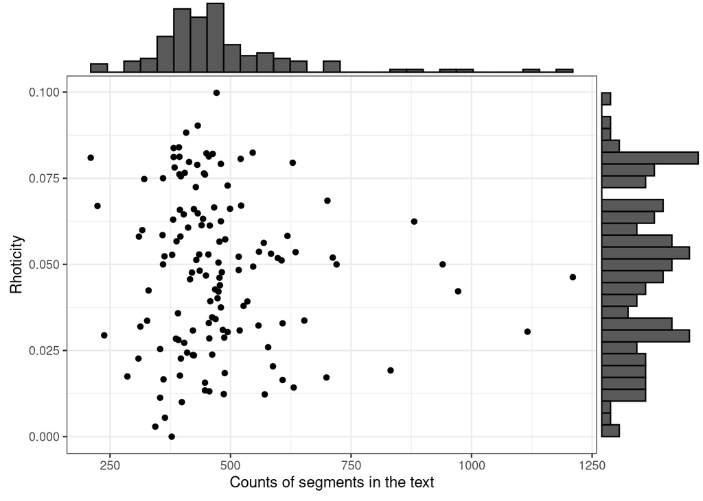

*Figure 12.* *Overall rhoticity*

We give the following values for the segments count:

- Maximum = 1210
- Minimum = 210
- Mean = 477.4
- Median = 450
- Standard deviation (sd) = 148.5
- Interquartile range (IQR) = 122.5

We give the following values for the rhoticity frequency:

- Maximum = 0.1
- Minimum = 0
- Mean = 0.048
- Median = 0.05
- Standard deviation (sd) = 0.023
- Interquartile range (IQR) = 0.035

#### Trill frequency

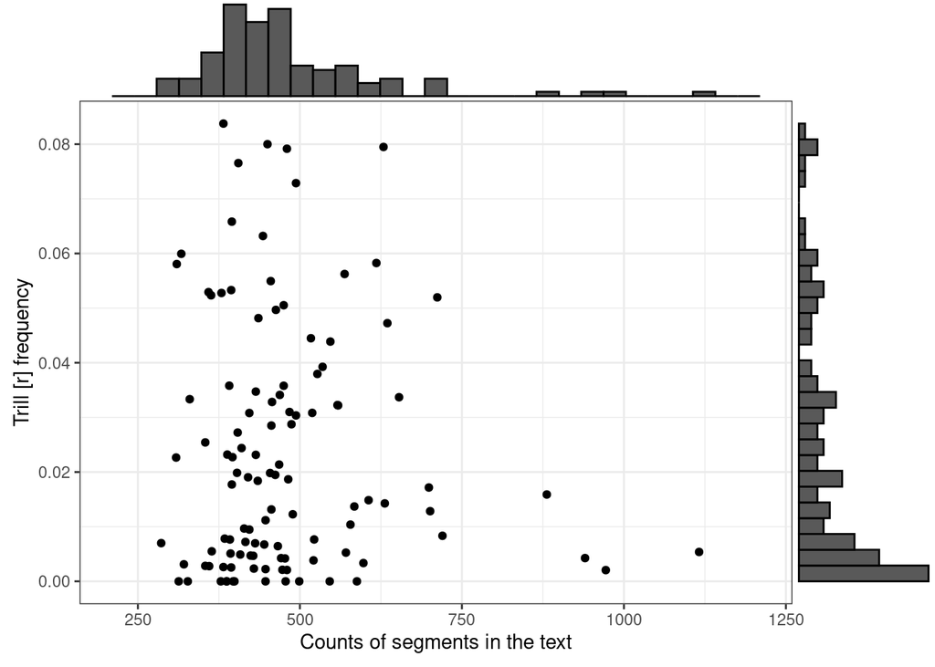

*Figure 13.* *Phonetic trills frequency*

We give the following values for the phonetic trill frequency:

- Maximum = 0.084
- Minimum = 0
- Mean = 0.024
- Median = 0.018
- Standard deviation (sd) = 0.023
- Interquartile range (IQR) = 0.031

12 Illustrations that do not contain [r] in their transcription.

We performed a Wilcoxon test showing that the trill frequency is thus significantly lower than the mean of rhoticity (*p*=1.75e-14).

- 43 Illustrations where there is only one rhotic segment in consonant chart
- 28 Illustrations where there is more than one rhotic segment in consonant chart
- 2 Illustrations where there is no rhotic segment in consonant chart

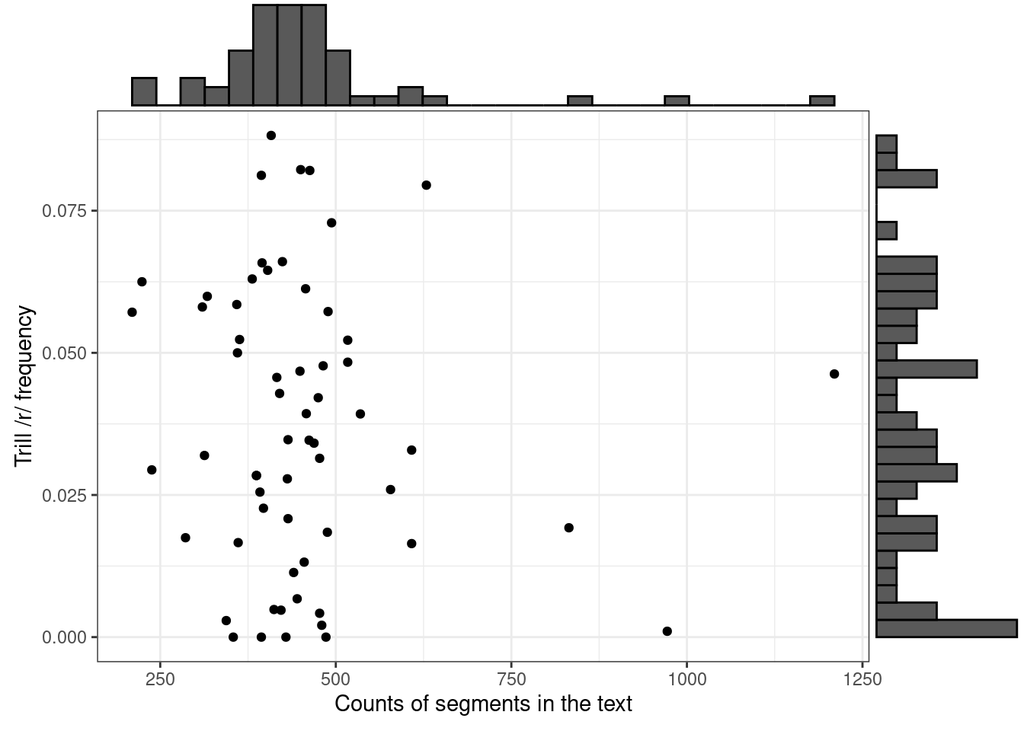

*Figure 14.* *Phonemic trills frequency*

We give the following values for the phonemic trill frequency:

- Maximum = 0.088
- Minimum = 0
- Mean = 0.037
- Median = 0.035
- Standard deviation (sd) = 0.025
- Interquartile range (IQR) = 0.04

Phonemic trill average frequency 0.037 is smaller than the average rhoticity 0.048. Phonemic trill average frequency 0.037 higher than that of the phonetic trill 0.024.

We performed a Kruskal–Wallis test to show if there are any significant differences for frequency values of phonemic trill, phonetic trill and rhoticity followed by a Dunn post hoc test. There are any significant differences for frequency values of phonemic trill, phonetic trill and rhoticity (*H*(2)=57.5188542,*p*=3.24e-13). The post hoc Dunn test shows that all the pairwise differences are statistically significantly different (*p_values* = 0.00528, 1.00589050183173e-13, 0.00137).

#### Tap frequency

We give the following values for the segments count in this new sample of 95 *Illustrations*, the average rhoticity is 0.048:

- Maximum = 2410
- Minimum = 208
- Mean = 488
- Median = 445
- Standard deviation (sd) = 230.2
- Interquartile range (IQR) = 116

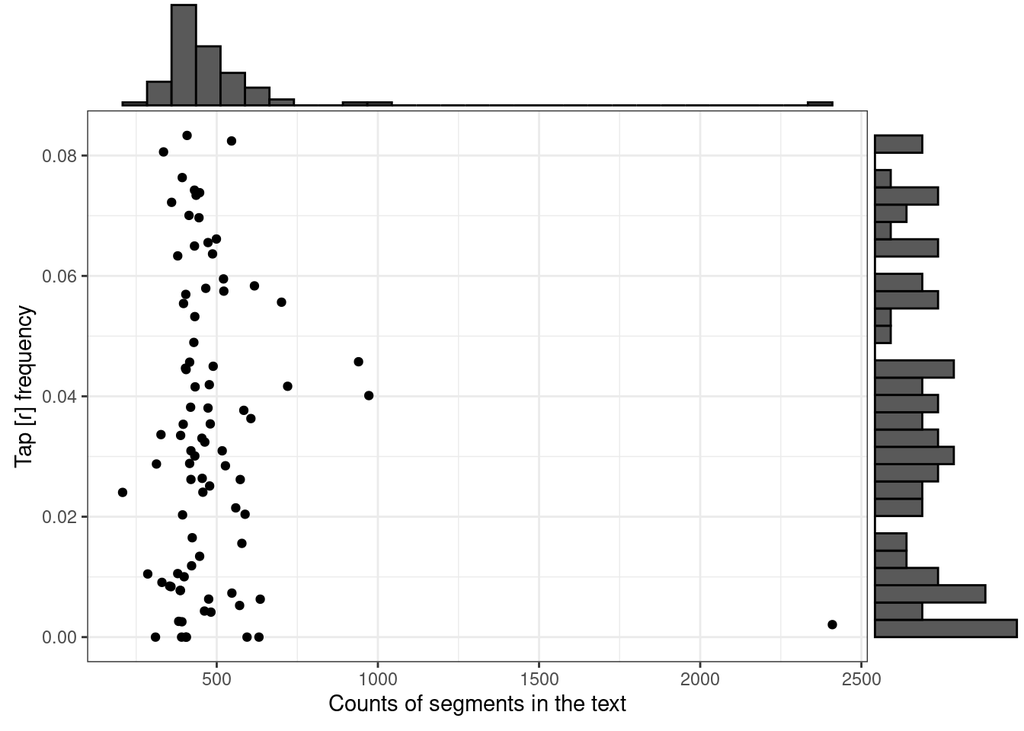

*Figure 15.* *Phonemtic taps frequency*

We give the following values for the phonetic trill frequency:

- Maximum = 0.083
- Minimum = 0 (corresponding to 6 *Illustrations* that does not contain a ɾ tap symbol.)
- Mean = 0.034
- Median = 0.032
- Standard deviation (sd) = 0.024
- Interquartile range (IQR) = 0.045

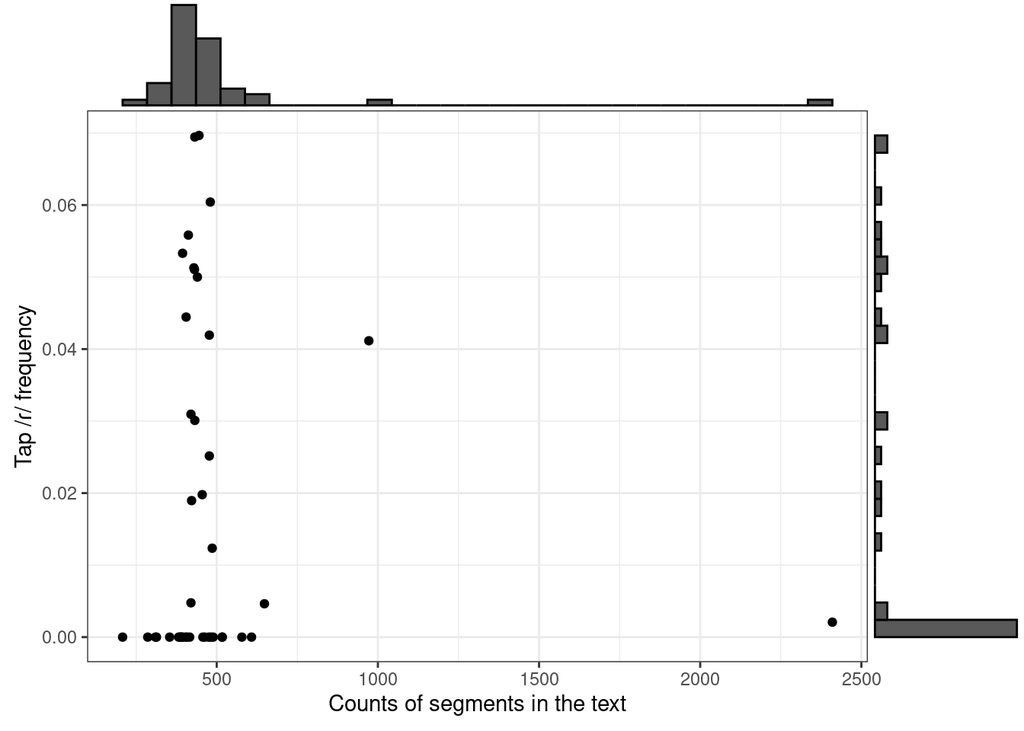

*Figure 16.* *Phonemic taps frequency*

We give the following values for the phonemic trill frequency:

- Maximum = 0.07
- Minimum = 0
- Mean = 0.02
- Median = 0
- Standard deviation (sd) = 0.024
- Interquartile range (IQR) = 0.039

We performed a Kruskal–Wallis test to show if there are any significant differences for frequency values of phonemic tap, phonetic tap and rhoticity followed by a Dunn post hoc test. There are any significant differences for frequency values of phonemic tap, phonetic tap and rhoticity (*H*(2)=43.451693,*p*=3.67e-10). The post hoc Dunn test shows that all the pairwise differences are statistically significantly different (*p_values* = 2.69362243360624e-10, 0.000717731317021716, 0.000717731317021716).

We performed a Kruskal–Wallis test to show if there are any significant differences for frequency values of phonemic trill, phonemic tap, phonetic trill, phonetic tap and rhoticity followed by a Dunn post hoc test.

There are any significant differences for frequency values of phonemic tap, phonetic tap and rhoticity (*H*(4)=82.234175,*p*=5.86e-17). The post hoc Dunn test shows that:

- phonetic trills [r] frequency was not significantly different from the phonemic taps frequency /ɾ/ (*p_value* = 0.14486731654953)
- phonemic trills /r/ frequency was not significantly different from the phonetic tap [ɾ] frequency (*p_value* = 0.516361992073119)
- /r/ are more frequent than /ɾ/ (*p_value* = 0.000187286855914644)
- [r] is less frequent than [ɾ] (*p_value* = 0.0163907001446172)

## Re-analysis based on Associate Editor comments

We decided to re-consider that all transcriptions lacking of explicit mention of *phonetic*/*phonemic*/*broad*/*narrow* (here considered as *unknown*) should be considered as *phonetic* or *phonemic* depending on the comparison of the symbols present in the consonant chart and those present in the narrative transcription. If some segments were present in the narrative but not in the consonant chart, then the transcription could be considered as *phonetic* otherwise it would be *phonemic*.

So, over the 213 illustrations, we have in total :

- 143 phonetic transcriptions
- 123 phonemic transcriptions

Including:

- 54 illustrations with a phonetic transcription and a phonemic transcription
- 89 illustrations with only a phonetic transcription
- 69 illustrations with only a phonemic transcription
- 1 illustrations with no transcription

As an exemple of *Illustrations* with an *r* we give the following:

| Title | quality_ling_trans | new_symbol_comment |
| --- | --- | --- |
| Basaá | unknown | presence of the alveolar trill symbol |
| Czech spoken in Bohemia and Moravia | unknown | presence of tap symbols |
| Ibibio | unknown | presence of symbols of trill alveolar and uvular and of tap |
| Indonesian | unknown | presence of trill and tap symbols while there is only one rhotic phoneme |
| Kera | unknown | presence of the symbol of alveolar trill |
| Kumzari | unknown | presence of the alveolar trill symbol |
| Mambay | unknown | presence of symbol of the alveolar trill and many diacritics |
| Mennonite Plautdietsch (Canadian Old Colony) | unknown | presence of the tap symbol |
| Mono | unknown | presence of the geminate of the alveolar trill |
| New Zealand English | unknown | presence of a alveolar trill symbol |
| Slovak | unknown | presence of the syllabic diacritic for the alveolar trill |
| Southeastern Pashayi | unknown | presence of alveolar tap symbols |
| Tilquiapan Zapotec | unknown | presence of a alveolar trill symbol |
| Croatian | unknown | presence of alveolar trill symbol with syllabic diacritic and gemination |
| Cypriot Greek | unknown | presence of alveolar trill symbol |
| German | unknown | presence of alveolar trill symbol and voiceless fricative uvular (maybe) |
| Standard Modern Greek | unknown | presence of alveolar trill symbol and devoising diacritic for the back close vowel |
| Swedish | unknown | presence of alveolar trill symbol |
| Tukang Besi | unknown | presence of many symbols for the rhotic |
| The dialect of Maastricht | unknown | presence of alveolar trill symbol |
| American English from Central Texas | unknown | no table but presence of several segment symbols for the rhotic |

We also give example where other symbols were used to decide either the transcription was *phonetic* or *phonemic* :

| Title | quality_ling_trans | new_symbol_comment |
| --- | --- | --- |
| Chistabino (Pyrenean Argonese) | unknown | approximants set for plosives set |
| Estonian | unknown | gemination and other diacritics |
| Murcian Spanish | unknown | presence of approximants for the plosive set |
| Standard Austrian German | unknown | presence of voiced uvular frivative |
| Standard Yiddish | unknown | presence of voiceless diacritic |
| Asturian | unknown | presence of approximants for the plosive set and diacritics |
| Catalan | unknown | presence of approximants for the plosive set |
| Galician | unknown | presence of approximant symbols set |
| Hungarian | unknown | presence of half long vowel diacritics |
| American English from Eastern Massachusetts | unknown | no table but transcription different for the two speaker |
| A phonetic description of the consonant system of Standard Dutch (ABN) | unknown | presence of diacritric below the fricative |

As we are mainly interested in *r*, we have chosen to analyze only some illustrations. We counted the possible cases with an *r*. In other words, we looked at the illustrations where:

- There is an /r/ present in the consonant table of the illustration
- There is at least one [r] or /r/ in one of the transcriptions

This gives us 136 illustrations to work with.

#### Illustrations with both phonemic and phonetic transcriptions _corr

[interactive chart not shown]

*Figure 17.* _Sankey diagram for counts of Illustrations with both phonemic and phonetic transcriptions when there is at least one r in the Illustration, focusing on the phonemic transcription (left), the consonant chart (middle) and the phonetic transcription (right). Plus symbol + means the presence of a symbol in the narrative transcriptions and minus symbol - its absence. *corr*

#### Illustrations with a phonetic transcription only _corr

[interactive chart not shown]

*Figure 18.* _Sankey diagram for counts of Illustrations with a phonetic transcription only when there is at least one r in the Illustration, focusing on the consonant chart (left) or on the phonetic transcription (right). *corr*

#### Illustrations with a phonemic transcription only _corr

[interactive chart not shown]

*Figure 19.* _Sankey diagram for counts of Illustrations with a phonemic transcription only when there is at least one r in the Illustration, focusing on the consonant chart (left) or on the phonemic transcription (right). *corr*

#### Trill frequency _corr

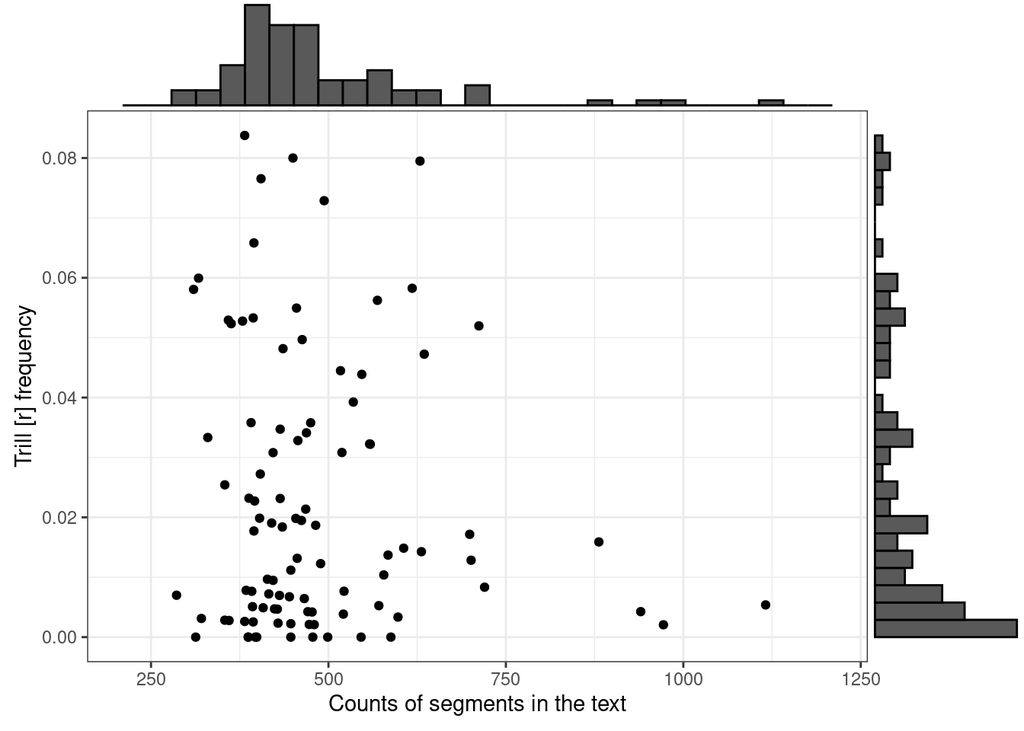

*Figure 20.* *Phonetic trills frequency*

We give the following values for the phonetic trill frequency:

- Maximum = 0.084
- Minimum = 0
- Mean = 0.023
- Median = 0.014
- Standard deviation (sd) = 0.023
- Interquartile range (IQR) = 0.03

10 Illustrations that do not contain [r] in their transcription.

We performed a Wilcoxon test showing that the trill frequency is thus significantly lower than the mean of rhoticity (*p*=1.52e-14).

- 43 Illustrations where there is only one rhotic segment in consonant chart
- 27 Illustrations where there is more than one rhotic segment in consonant chart
- 2 Illustrations where there is no rhotic segment in consonant chart

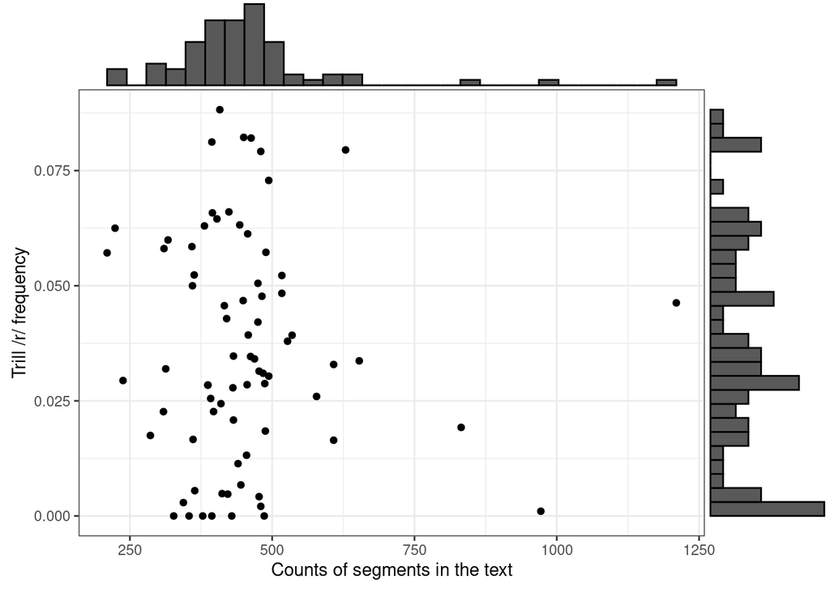

*Figure 21.* *Phonemic trills frequency*

We give the following values for the phonemic trill frequency:

- Maximum = 0.088
- Minimum = 0
- Mean = 0.036
- Median = 0.033
- Standard deviation (sd) = 0.024
- Interquartile range (IQR) = 0.037

Phonemic trill average frequency 0.036 is smaller than the average rhoticity 0.048. Phonemic trill average frequency 0.036 higher than that of the phonetic trill 0.023.

We performed a Kruskal–Wallis test to show if there are any significant differences for frequency values of phonemic trill, phonetic trill and rhoticity followed by a Dunn post hoc test. There are any significant differences for frequency values of phonemic trill, phonetic trill and rhoticity (*H*(2)=58.4419195,*p*=2.04e-13). The post hoc Dunn test shows that all the pairwise differences are statistically significantly different (*p_values* = 0.00101, 6.72567095914084e-14, 0.00083).

#### Tap frequency _corr

We give the following values for the segments count in this new sample of 95 *Illustrations*, the average rhoticity is 0.048:

- Maximum = 2410
- Minimum = 208
- Mean = 488
- Median = 445
- Standard deviation (sd) = 230.2
- Interquartile range (IQR) = 116

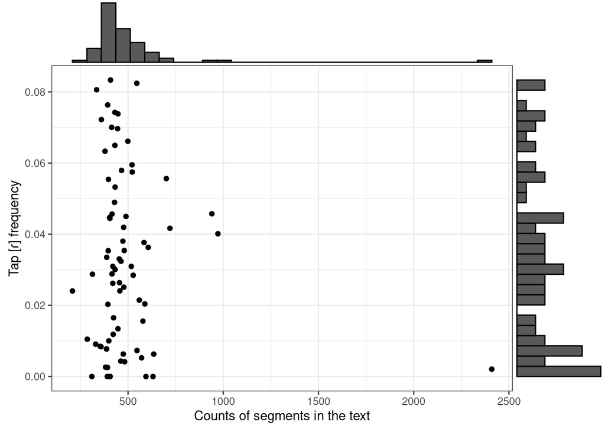

*Figure 22.* *Phonetic taps frequency*

We give the following values for the phonetic trill frequency:

- Maximum = 0.083
- Minimum = 0 (corresponding to 6 *Illustrations* that does not contain a ɾ tap symbol.)
- Mean = 0.032
- Median = 0.03
- Standard deviation (sd) = 0.025
- Interquartile range (IQR) = 0.039

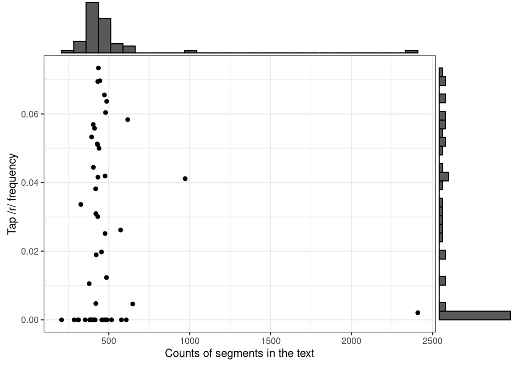

*Figure 23.* *Phonemic taps frequency*

We give the following values for the phonemic trill frequency:

- Maximum = 0.073
- Minimum = 0
- Mean = 0.02
- Median = 0
- Standard deviation (sd) = 0.026
- Interquartile range (IQR) = 0.046

We performed a Kruskal–Wallis test to show if there are any significant differences for frequency values of phonemic tap, phonetic tap and rhoticity followed by a Dunn post hoc test. There are any significant differences for frequency values of phonemic tap, phonetic tap and rhoticity (*H*(2)=35.2631775,*p*=2.2e-08). The post hoc Dunn test shows that all the pairwise differences are statistically significantly different (*p_values* = 4.47548458150088e-08, 0.000208812205665386, 0.0364694299478496).

We performed a Kruskal–Wallis test to show if there are any significant differences for frequency values of phonemic trill, phonemic tap, phonetic trill, phonetic tap and rhoticity followed by a Dunn post hoc test.

There are any significant differences for frequency values of phonemic tap, phonetic tap and rhoticity (*H*(4)=73.0609136,*p*=5.12e-15). The post hoc Dunn test shows that:

- phonetic trills [r] frequency was not significantly different from the phonemic taps frequency /ɾ/ (*p_value* = 0.816299449977097)
- phonemic trills /r/ frequency was not significantly different from the phonetic tap [ɾ] frequency (*p_value* = 0.816299449977097)
- /r/ are more frequent than /ɾ/ (*p_value* = 0.0115508756517654)
- [r] is less frequent than [ɾ] (*p_value* = 0.049894224387323)

# References

## Packages used

| Packages | Version |
| --- | --- |
| networkD3 | 0.4 |
| forcats | 0.5.1 |
| gridExtra | 2.3 |
| sjPlot | 2.8.10 |
| rstatix | 0.7.0 |
| knitr | 1.39 |
| stringr | 1.4.0 |
| ggExtra | 0.10.0 |
| ggplot2 | 3.3.6 |
| dplyr | 1.0.9 |
| magrittr | 2.0.3 |

## RStudio version

```
## $citation
##
##
##   RStudio Team (2020). RStudio: Integrated Development Environment for
##   R. RStudio, PBC, Boston, MA URL http://www.rstudio.com/.
##
## A BibTeX entry for LaTeX users is
##
##   @Manual{,
##     title = {RStudio: Integrated Development Environment for R},
##     author = {{RStudio Team}},
##     organization = {RStudio, PBC},
##     address = {Boston, MA},
##     year = {2020},
##     url = {http://www.rstudio.com/},
##   }
##
##
## $mode
## [1] "desktop"
##
## $version
## [1] '1.3.1073'
##
## $release_name
## [1] "Giant Goldenrod"
```